# Assignment 1

# Machine Learning: Seed Classification

*by: Márió Palágyi*

## Description:

“You need to train a ML (classification) model that is capable of distinguishing among three different types of seeds based on their measurements (perimeter, area, length, etc.). Using decision trees, create models that take as input the measurements and predict the class of the seed.”

In particular:

- Import the attached dataset
- Perform the necessary manipulation
- Perform a short exploration (summary, main descriptive plots, …)
- Split in train/test (80/20)
- Use the training set to train:

a decision tree, using with default stopping criterion

a decision tree, without stopping criterion (complete)

a decision tree, pruned from b.

- Use the test set to create the confusion matrix and present the main metrics of the three models.
- REPEAT the exercise using only three measurements of your choice (i.e., three columns) instead of all of them. Does the performance substantially decrease?

# Tasks

## 0. Setup

```r
# Setup; messages and warnings switched off

# Set WD to the folder of the currently opened r file
if (rstudioapi::isAvailable())
  setwd(dirname(rstudioapi::getActiveDocumentContext()[["path"]]))

# Load libraries
library(data.table)
library(plotly)
library(rpart)
library(rpart.plot)
library(caret)
```

## 1. Import attached dataset - seeds.csv

```r
seeds <- fread("./data/seeds.csv")
```

## 2. Perform the necessary manipulation

```r
str(seeds)
```

```
## Classes 'data.table' and 'data.frame':   8209 obs. of  17 variables:
##  $ Area           : int  37663 25423 36982 38687 32795 26163 42522 42242 35699 38782 ...
##  $ Perimeter      : num  712 590 709 722 651 ...
##  $ MajorAxisLength: num  234 221 244 266 225 ...
##  $ MinorAxisLength: num  206 146 193 185 186 ...
##  $ AspectRation   : num  1.13 1.51 1.27 1.44 1.21 ...
##  $ Eccentricity   : num  0.473 0.751 0.614 0.717 0.566 ...
##  $ ConvexArea     : int  38084 25739 37558 39030 33091 26435 43001 42734 36104 39152 ...
##  $ EquivDiameter  : num  219 180 217 222 204 ...
##  $ Extent         : num  0.754 0.764 0.76 0.804 0.776 ...
##  $ Solidity       : num  0.989 0.988 0.985 0.991 0.991 ...
##  $ roundness      : num  0.933 0.917 0.925 0.932 0.972 ...
##  $ Compactness    : num  0.938 0.812 0.888 0.834 0.907 ...
##  $ ShapeFactor1   : num  0.0062 0.00871 0.00661 0.00688 0.00687 ...
##  $ ShapeFactor2   : num  0.00296 0.00234 0.00253 0.00205 0.00287 ...
##  $ ShapeFactor3   : num  0.879 0.66 0.788 0.696 0.823 ...
##  $ ShapeFactor4   : num  0.997 0.999 0.998 0.998 0.999 ...
##  $ Class          : chr  "SEKER" "DERMASON" "SEKER" "SIRA" ...
##  - attr(*, ".internal.selfref")=<externalptr>
```

We can see that the Class column is interpreted as characters. We need to transform it into factors.

```r
seeds[, Class := as.factor(Class)] # transform categorical to factor
str(seeds$Class) # Correct factor
```

```
##  Factor w/ 3 levels "DERMASON","SEKER",..: 2 1 2 3 2 1 3 3 2 1 ...
```

Check empty cells and fix

```r
#Check empty
any(is.na(seeds))
```

```
## [1] TRUE
```

```r
sum(is.na(seeds))
```

```
## [1] 4
```

```r
colSums(is.na(seeds))
```

```
##            Area       Perimeter MajorAxisLength MinorAxisLength    AspectRation
##               0               0               0               0               0
##    Eccentricity      ConvexArea   EquivDiameter          Extent        Solidity
##               1               0               0               0               3
##       roundness     Compactness    ShapeFactor1    ShapeFactor2    ShapeFactor3
##               0               0               0               0               0
##    ShapeFactor4           Class
##               0               0
```

```r
# Manipulation to transform empty values
# make sure fread handles missing values from ",," correctly to "NA"
seeds[is.na(seeds$Eccentricity),
      Eccentricity := mean(seeds$Eccentricity, na.rm = TRUE)]
seeds[is.na(seeds$Solidity),
      Solidity := mean(seeds$Solidity, na.rm = TRUE)]

print(c("Number of empty cells after imputation:", sum(is.na(seeds))))
```

```
## [1] "Number of empty cells after imputation:"
## [2] "0"
```

We can see that among other attributes, in the last column we have the classes of the seeds. There are 3 types of seeds, Seker, Dermasion and Sira. At first, these values were handled as characters, so I factorized them.

We also discovered that there were 4 empty cells: 1 was in Eccentricity and 3 in Solidity. The options are either omit them or take the mean of the columns. I chose the latter option, the mean imputation.

## 3. Perform a short exploration (summary, main descriptive plots, …)

```r
summary(seeds)
```

```
##       Area         Perimeter     MajorAxisLength MinorAxisLength
##  Min.   :20420   Min.   :524.7   Min.   :183.6   Min.   :122.5
##  1st Qu.:32757   1st Qu.:669.4   1st Qu.:240.6   1st Qu.:168.2
##  Median :38137   Median :720.6   Median :260.1   Median :185.3
##  Mean   :38085   Mean   :722.8   Mean   :264.7   Mean   :182.7
##  3rd Qu.:43315   3rd Qu.:776.8   3rd Qu.:287.2   3rd Qu.:196.5
##  Max.   :63612   Max.   :984.3   Max.   :400.9   Max.   :252.3
##   AspectRation    Eccentricity      ConvexArea    EquivDiameter
##  Min.   :1.025   Min.   :0.2190   Min.   :20684   Min.   :161.2
##  1st Qu.:1.346   1st Qu.:0.6695   1st Qu.:33131   1st Qu.:204.2
##  Median :1.479   Median :0.7368   Median :38554   Median :220.4
##  Mean   :1.455   Mean   :0.7090   Mean   :38519   Mean   :219.2
##  3rd Qu.:1.564   3rd Qu.:0.7688   3rd Qu.:43828   3rd Qu.:234.8
##  Max.   :2.010   Max.   :0.8675   Max.   :64581   Max.   :284.6
##      Extent          Solidity        roundness       Compactness
##  Min.   :0.6275   Min.   :0.9192   Min.   :0.4896   Min.   :0.7034
##  1st Qu.:0.7276   1st Qu.:0.9875   1st Qu.:0.8884   1st Qu.:0.7982
##  Median :0.7630   Median :0.9891   Median :0.9102   Median :0.8208
##  Mean   :0.7564   Mean   :0.9887   Mean   :0.9096   Mean   :0.8313
##  3rd Qu.:0.7860   3rd Qu.:0.9905   3rd Qu.:0.9329   3rd Qu.:0.8608
##  Max.   :0.8528   Max.   :0.9942   Max.   :0.9907   Max.   :0.9873
##   ShapeFactor1       ShapeFactor2       ShapeFactor3     ShapeFactor4
##  Min.   :0.005056   Min.   :0.000987   Min.   :0.4947   Min.   :0.9477
##  1st Qu.:0.006502   1st Qu.:0.001770   1st Qu.:0.6372   1st Qu.:0.9959
##  Median :0.006898   Median :0.002068   Median :0.6737   Median :0.9974
##  Mean   :0.007072   Mean   :0.002101   Mean   :0.6933   Mean   :0.9968
##  3rd Qu.:0.007594   3rd Qu.:0.002400   3rd Qu.:0.7410   3rd Qu.:0.9984
##  Max.   :0.010451   Max.   :0.003665   Max.   :0.9748   Max.   :0.9997
##       Class
##  DERMASON:3546
##  SEKER   :2027
##  SIRA    :2636
##
##
##
```

```r
seeds[, .N, "Class"]
```

```
##       Class     N
##      <fctr> <int>
## 1:    SEKER  2027
## 2: DERMASON  3546
## 3:     SIRA  2636
```

```r
# Single scatterplot for Compactness
a <- plot_ly(data = seeds, x = 1:nrow(seeds),
             y = ~Compactness,
             color =~Class,
             type = "scatter",
             mode = "markers",
             showlegend = F)
a
```

[interactive chart not shown]

```r
# Single boxplot for Compactness
b <- plot_ly(data = seeds, y = ~Compactness, x = ~nrow(seeds), type = "box")
b
```

[interactive chart not shown]

```r
# Code for creating a scatterplot for each feature
#plots <- list()
#for (i in colnames(seeds[, !"Class"])) {
#  plots[[i]] <- plot_ly(data = seeds, x = 1:nrow(seeds),
#                       y = seeds[,get(i)],
#                      color = seeds[,Class],
#                      type = "scatter", mode = "markers", showlegend = F)
#}
#subplot(plots, nrows = 8, titleY = T, margin = 0.05) # fix to look better

# Code for creating a boxplot for each feature
#plots <- list()
#for(i in colnames(seeds[,!"Class"])){
#  show_legend <- ifelse(i == "Area", TRUE, FALSE)
#  plots[[i]] <- plot_ly(data = seeds, x = seeds[,Class], y = seeds[,get(i)],
#                        color = seeds[,Class],
#                        type = "box", showlegend = show_legend) |>
#    layout(yaxis = list(title = i))
#}
#subplot(plots, nrows = 8, titleY = T, margin = 0.05)
```

Due to severe lagging and freeze, I decided not to output all plots. Please see the code for the solution. I opted, to choose Compactness as an example feature to plot, and looking at the output, Compactness is useful in predicting seed class.

## 4. Split in train/test (60/40)

```r
set.seed(12345)

idx <- createDataPartition(seeds[, Class], times=1, p = 0.6, list = F)

seeds_training <- seeds[idx]
seeds_test <- seeds[-idx]

#seeds[, .(.N, share = .N/nrow(seeds)), Class]
#seeds_training[, .(n_obs = .N, share = .N / nrow(seeds_training)), Class]
#seeds_test[, .(n_obs = .N, share = .N / nrow(seeds_test)), Class]
# create 2 new columns to show the number of objects, the share compared to all entries, both columns grouped by Class
```

## 5. Use the training set to train

- a decision tree, using with default stopping criterion
- a decision tree, without stopping criterion (complete)
- a decision tree, pruned from b.

### Default Criterion

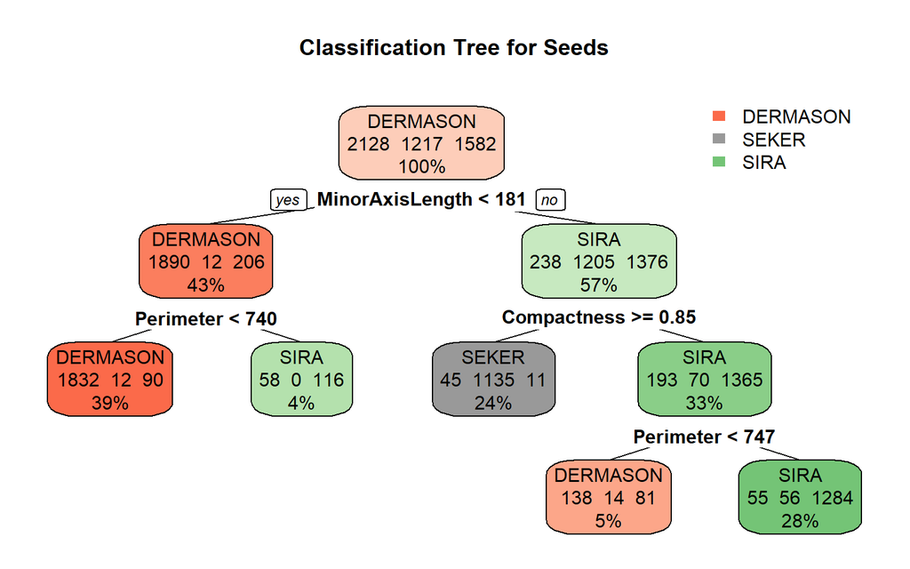

```r
# Decision tree, default stopping criterion
train_x <- seeds_training[, !"Class"]
train_y <- seeds_training[, Class]
test_x <- seeds_test[, !"Class"]
test_y <- seeds_test[, Class]

dtree_default <- rpart::rpart(Class ~ ., method = "class",
                              data =seeds_training)

rpart.plot(dtree_default, type = 2, extra = 101, fallen.leaves = F,
           main = "Classification Tree for Seeds")
```

```r
#print(dtree_default)
printcp(dtree_default) # shows cross-validation error - should be minimized
```

```
##
## Classification tree:
## rpart::rpart(formula = Class ~ ., data = seeds_training, method = "class")
##
## Variables actually used in tree construction:
## [1] Compactness     MinorAxisLength Perimeter
##
## Root node error: 2799/4927 = 0.56809
##
## n= 4927
##
##         CP nsplit rel error  xerror      xstd
## 1 0.406574      0   1.00000 1.00000 0.0124220
## 2 0.401572      1   0.59343 0.58557 0.0118157
## 3 0.020722      2   0.19185 0.19578 0.0078847
## 4 0.020364      3   0.17113 0.18792 0.0077442
## 5 0.010000      4   0.15077 0.18006 0.0075994
```

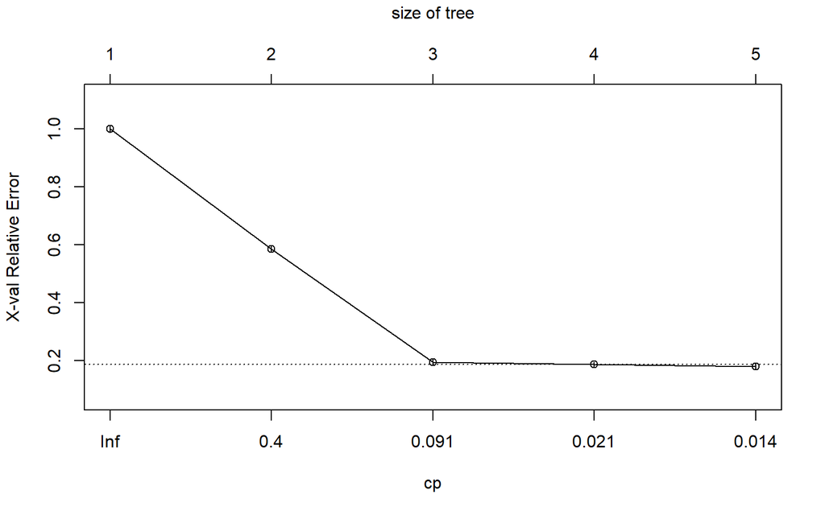

```r
plotcp(dtree_default) #Notes: CP means complexity parameter (lower, complexer); X-val is cross validation (lower, better); the dotted line is the error bar: Minimum error + (Standard Error of the Minimum Error), If a tree's error is within this dotted line range, it's considered statistically equivalent to the best (lowest error) tree.
```

```r
#summary(dtree_default)
```

Since we used the function of the rpart library, k-fold cross-validation was automatically performed for us, k=10. Using printcp, we already received the important cross-validation error values. The model grew the tree until we reached a complexity parameter of 0.01, where it defaultly stopped.

From the output we can deduce the following from the model with default stopping criterion (cp = 0.01): - at the first and second splits, the cross-validation error significantly lowers - the cross validation error stabilizes after the 2nd split - after the 2nd split, our model’s prediction accuracy doesn’t significantly improve, suggesting that at the tree size of 3 or 4, we have our most **parsimonius model** *(new word that I found…)*, meaning the model achieves good prediction accuracy, without being too complex.

### Full tree (no stopping criterion)

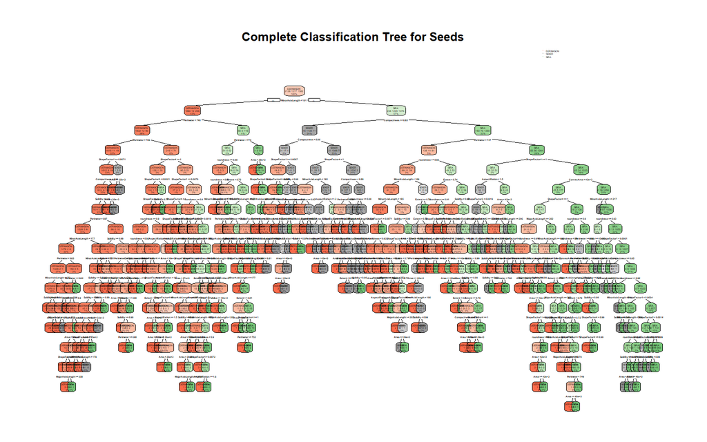

```r
# Decision tree, without stopping criterion (complete)
dtree_full <- rpart::rpart(Class ~ ., method = "class",
                           data = seeds_training,
                           control = rpart.control(minsplit = 1, cp = 0))

rpart.plot(dtree_full, type = 2, extra = 101, fallen.leaves = F,
           main = "Complete Classification Tree for Seeds")
```

```r
printcp(dtree_full)
```

```
##
## Classification tree:
## rpart::rpart(formula = Class ~ ., data = seeds_training, method = "class",
##     control = rpart.control(minsplit = 1, cp = 0))
##
## Variables actually used in tree construction:
##  [1] Area            AspectRation    Compactness     ConvexArea
##  [5] Extent          MajorAxisLength MinorAxisLength Perimeter
##  [9] roundness       ShapeFactor1    ShapeFactor2    ShapeFactor4
## [13] Solidity
##
## Root node error: 2799/4927 = 0.56809
##
## n= 4927
##
```

[output cut: 25 more lines]

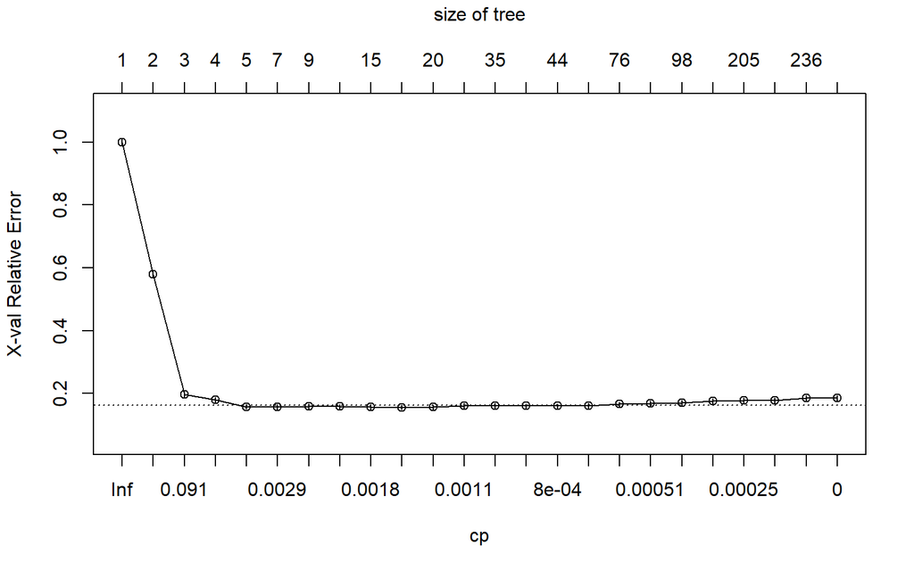

```r
plotcp(dtree_full)
```

As we can see, creating a decision tree without a stopping criterion results in a seriously complex model, most likely overfitted.

### Pruned tree

```r
# Decision tree, pruned from b)
which.min(dtree_full$cptable[, "xerror"]) # 10
```

```
## 10
## 10
```

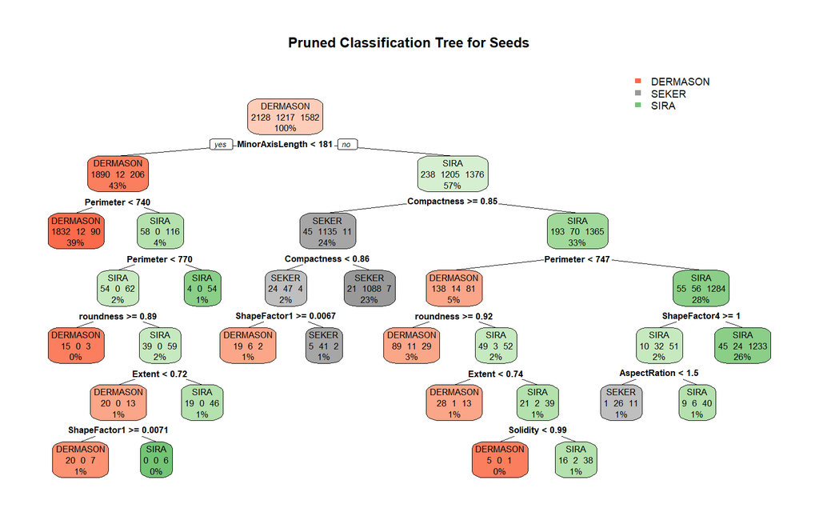

```r
# 10 0.00125045     15  0.123973 0.15613 0.0071297 --- from previous table

prune_optimal_cp <- dtree_full$cptable[which.min(dtree_full$cptable[, "xerror"]), "CP"]
dtree_pruned <- prune(dtree_full, cp = prune_optimal_cp)

rpart.plot(dtree_pruned, type = 2, extra = 101, fallen.leaves = F,
           main = "Pruned Classification Tree for Seeds")
```

```r
printcp(dtree_pruned)
```

```
##
## Classification tree:
## rpart::rpart(formula = Class ~ ., data = seeds_training, method = "class",
##     control = rpart.control(minsplit = 1, cp = 0))
##
## Variables actually used in tree construction:
## [1] AspectRation    Compactness     Extent          MinorAxisLength
## [5] Perimeter       roundness       ShapeFactor1    ShapeFactor4
## [9] Solidity
##
## Root node error: 2799/4927 = 0.56809
##
## n= 4927
##
##           CP nsplit rel error  xerror      xstd
## 1  0.4065738      0   1.00000 1.00000 0.0124220
## 2  0.4015720      1   0.59343 0.57949 0.0117847
## 3  0.0207217      2   0.19185 0.19650 0.0078972
## 4  0.0203644      3   0.17113 0.18006 0.0075994
## 5  0.0032154      4   0.15077 0.15791 0.0071664
## 6  0.0026795      6   0.14434 0.15720 0.0071517
## 7  0.0023223      8   0.13898 0.15899 0.0071882
## 8  0.0021436     10   0.13433 0.15827 0.0071737
## 9  0.0014291     14   0.12540 0.15720 0.0071517
## 10 0.0012504     15   0.12397 0.15613 0.0071297
```

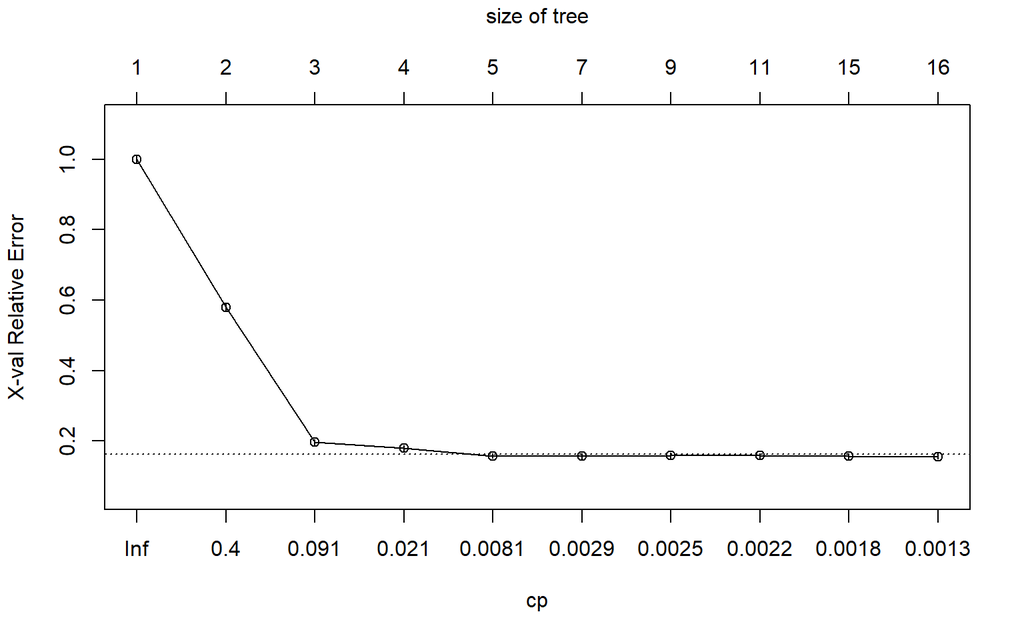

```r
plotcp(dtree_pruned)
```

Now we have our final pruned classification tree, at 15 splits, with **cross-validation error** at **0.1561** and **complexity parameter** at **0.0012504.** *Result:* We found the overall most parsimonious/efficient classification tree, which has the overall lowest cross-validation error while not overfitting (complexity is not too complex). This is also proved by looking at the plotcp generated plot, where the point falls below the dotted line, error bar.

## 6. Use the test set to create the confusion matrix and present the main metrics of the three

```r
predict_y_dtree_default <- predict(dtree_default, newdata = test_x, type = "class") # learn from dtree_default, predict on test_x
predict_y_dtree_full <- predict(dtree_full, newdata = test_x, type = "class")
predict_y_dtree_pruned <- predict(dtree_pruned, newdata = test_x, type = "class")

table(predict_y_dtree_default,test_y); table(predict_y_dtree_full,test_y); table(predict_y_dtree_pruned,test_y) # raw confusion matrices
```

```
##                        test_y
## predict_y_dtree_default DERMASON SEKER SIRA
##                DERMASON     1290    15  111
##                SEKER          32   744   11
##                SIRA           96    51  932
```

```
##                     test_y
## predict_y_dtree_full DERMASON SEKER SIRA
##             DERMASON     1258    28  119
##             SEKER          30   754   36
##             SIRA          130    28  899
```

```
##                       test_y
## predict_y_dtree_pruned DERMASON SEKER SIRA
##               DERMASON     1302    15  117
##               SEKER          26   761   22
##               SIRA           90    34  915
```

Default Tree:

```r
confusionMatrix(predict_y_dtree_default, reference=test_y, mode="prec_recall")
```

```
## Confusion Matrix and Statistics
##
##           Reference
## Prediction DERMASON SEKER SIRA
##   DERMASON     1290    15  111
##   SEKER          32   744   11
##   SIRA           96    51  932
##
## Overall Statistics
##
##                Accuracy : 0.9037
##                  95% CI : (0.8931, 0.9136)
##     No Information Rate : 0.4321
##     P-Value [Acc > NIR] : < 2.2e-16
##
##                   Kappa : 0.8516
##
##  Mcnemar's Test P-Value : 3.155e-07
##
## Statistics by Class:
##
##                      Class: DERMASON Class: SEKER Class: SIRA
## Precision                     0.9110       0.9454      0.8638
## Recall                        0.9097       0.9185      0.8843
## F1                            0.9104       0.9317      0.8739
## Prevalence                    0.4321       0.2468      0.3211
## Detection Rate                0.3931       0.2267      0.2840
## Detection Prevalence          0.4314       0.2398      0.3288
## Balanced Accuracy             0.9211       0.9506      0.9091
```

Full Tree:

```r
confusionMatrix(predict_y_dtree_full, reference=test_y, mode="prec_recall")
```

```
## Confusion Matrix and Statistics
##
##           Reference
## Prediction DERMASON SEKER SIRA
##   DERMASON     1258    28  119
##   SEKER          30   754   36
##   SIRA          130    28  899
##
## Overall Statistics
##
##                Accuracy : 0.887
##                  95% CI : (0.8756, 0.8976)
##     No Information Rate : 0.4321
##     P-Value [Acc > NIR] : <2e-16
##
##                   Kappa : 0.8261
##
##  Mcnemar's Test P-Value : 0.6697
##
## Statistics by Class:
##
##                      Class: DERMASON Class: SEKER Class: SIRA
## Precision                     0.8954       0.9195      0.8505
## Recall                        0.8872       0.9309      0.8529
## F1                            0.8913       0.9252      0.8517
## Prevalence                    0.4321       0.2468      0.3211
## Detection Rate                0.3833       0.2297      0.2739
## Detection Prevalence          0.4281       0.2498      0.3221
## Balanced Accuracy             0.9042       0.9521      0.8910
```

Pruned Tree:

```r
confusionMatrix(predict_y_dtree_pruned, reference=test_y, mode="prec_recall")
```

```
## Confusion Matrix and Statistics
##
##           Reference
## Prediction DERMASON SEKER SIRA
##   DERMASON     1302    15  117
##   SEKER          26   761   22
##   SIRA           90    34  915
##
## Overall Statistics
##
##                Accuracy : 0.9074
##                  95% CI : (0.8969, 0.9171)
##     No Information Rate : 0.4321
##     P-Value [Acc > NIR] : < 2e-16
##
##                   Kappa : 0.8572
##
##  Mcnemar's Test P-Value : 0.02871
##
## Statistics by Class:
##
##                      Class: DERMASON Class: SEKER Class: SIRA
## Precision                     0.9079       0.9407      0.8807
## Recall                        0.9182       0.9395      0.8681
## F1                            0.9130       0.9401      0.8743
## Prevalence                    0.4321       0.2468      0.3211
## Detection Rate                0.3967       0.2319      0.2788
## Detection Prevalence          0.4369       0.2465      0.3166
## Balanced Accuracy             0.9237       0.9600      0.9062
```

As we can see on the confusion matrices and the most important metrics, like Precision, Recall and F1-score, the pruned tree returns the best prediction results.

### 7.REPEAT the exercise using only three measurements of your choice

(i.e., three columns) instead of all of them. Does the performance substantially decrease?

```r
# varImp from caret package
varImp(dtree_default)
```

```
##                   Overall
## Area             221.7929
## AspectRation    2091.3987
## Compactness     2104.8126
## ConvexArea       225.4786
## Eccentricity    1040.4274
## EquivDiameter    221.7929
## MajorAxisLength  211.4218
## MinorAxisLength 1193.9074
## Perimeter        248.1705
## ShapeFactor1    1184.3041
## ShapeFactor2     985.4143
## ShapeFactor3    2104.8126
## Extent             0.0000
## Solidity           0.0000
## roundness          0.0000
## ShapeFactor4       0.0000
```

After some research I found that using varImp from the *caret* library might help us decide on which are the most influential features. The features that best help increasing the model predictability are the ones with the highest scores. Using these, our resulting model should have the best performance, even with just 3 features.

The chosen features: - **Compactness** (2104.8126) - **AspectRation** (2091.3987) - **ShapeFactor3** (2104.8126)

```r
seeds_3_training <- seeds_training[, c("AspectRation", "Compactness", "ShapeFactor3", "Class")]
seeds_3_test <- seeds_test[, c("AspectRation", "Compactness", "ShapeFactor3", "Class")]
```

In the following, we will create the 3 classification models, the one with the default stopping criterion, the one with the whole tree and the one that is pruned from the full tree.

### Default Tree

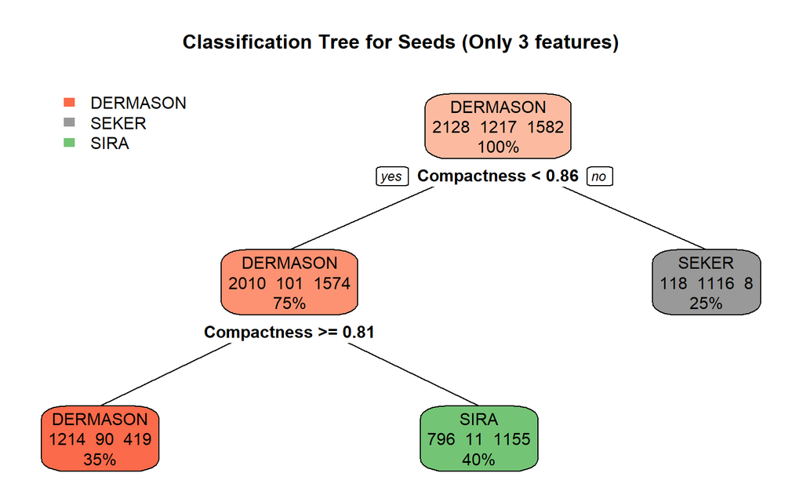

```r
# Decision tree, default stopping criterion
train_x <- seeds_3_training[, !"Class"]
train_y <- seeds_3_training[, Class]
test_x <- seeds_3_test[, !"Class"]
test_y <- seeds_3_test[, Class]

dtree_3_default <- rpart::rpart(Class ~ ., method = "class",
                              data =seeds_3_training)

rpart.plot(dtree_3_default, type = 2, extra = 101, fallen.leaves = F,
           main = "Classification Tree for Seeds (Only 3 features)")
```

```r
printcp(dtree_3_default)
```

```
##
## Classification tree:
## rpart::rpart(formula = Class ~ ., data = seeds_3_training, method = "class")
##
## Variables actually used in tree construction:
## [1] Compactness
##
## Root node error: 2799/4927 = 0.56809
##
## n= 4927
##
##        CP nsplit rel error  xerror     xstd
## 1 0.35656      0   1.00000 1.00000 0.012422
## 2 0.12826      1   0.64344 0.64416 0.012080
## 3 0.01000      2   0.51518 0.51733 0.011424
```

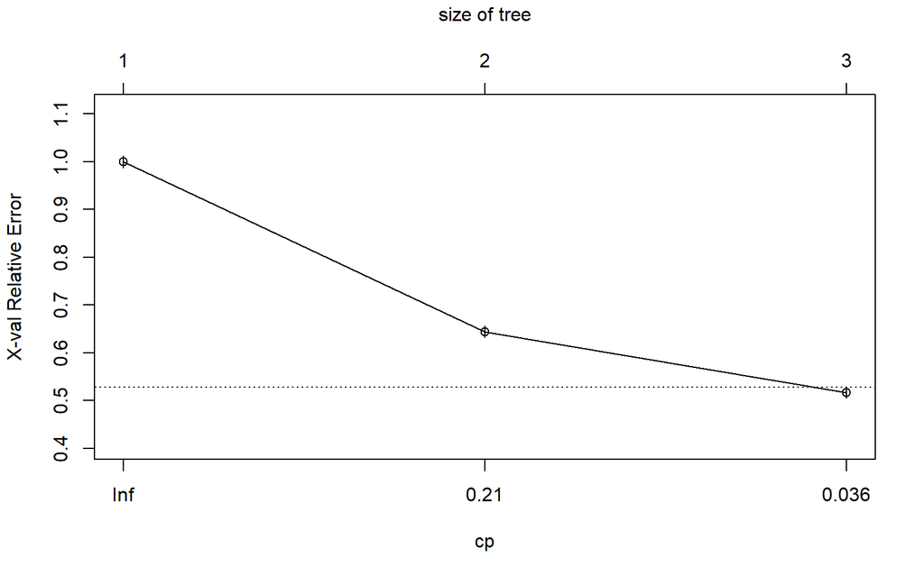

```r
plotcp(dtree_3_default)
```

### Full Tree

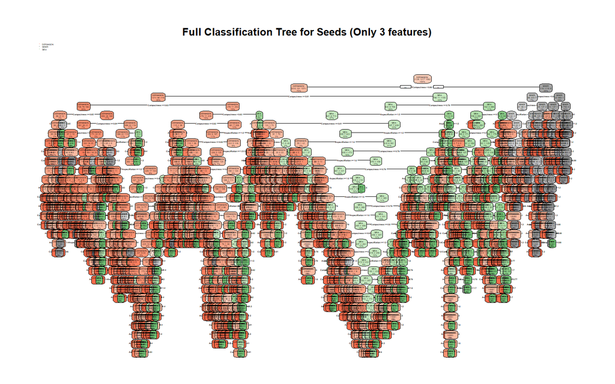

```r
dtree_3_full <- rpart::rpart(Class ~ ., method = "class",
                           data = seeds_3_training,
                           control = rpart.control(minsplit = 1, cp = 0))

rpart.plot(dtree_3_full, type = 2, extra = 101, fallen.leaves = F,
           main = "Full Classification Tree for Seeds (Only 3 features)")
```

```r
printcp(dtree_3_full)
```

```
##
## Classification tree:
## rpart::rpart(formula = Class ~ ., data = seeds_3_training, method = "class",
##     control = rpart.control(minsplit = 1, cp = 0))
##
## Variables actually used in tree construction:
## [1] AspectRation Compactness
##
## Root node error: 2799/4927 = 0.56809
##
## n= 4927
##
##            CP nsplit rel error  xerror     xstd
## 1  0.35655591      0  1.000000 1.00000 0.012422
## 2  0.12826009      1  0.643444 0.64452 0.012081
```

[output cut: 28 more lines]

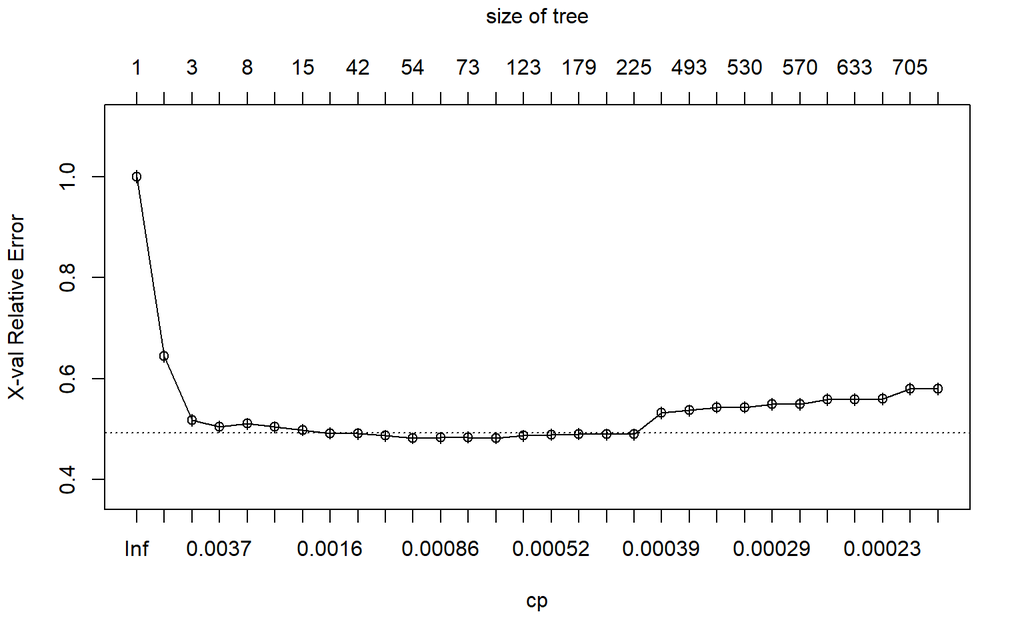

```r
plotcp(dtree_3_full)
```

From the results, it is obvious that the xerror doesn’t go well below 0.5. **Bad news…**

### Pruned Tree

```r
# Decision tree, pruned from b)
which.min(dtree_3_full$cptable[, "xerror"]) # 11
```

```
## 11
## 11
```

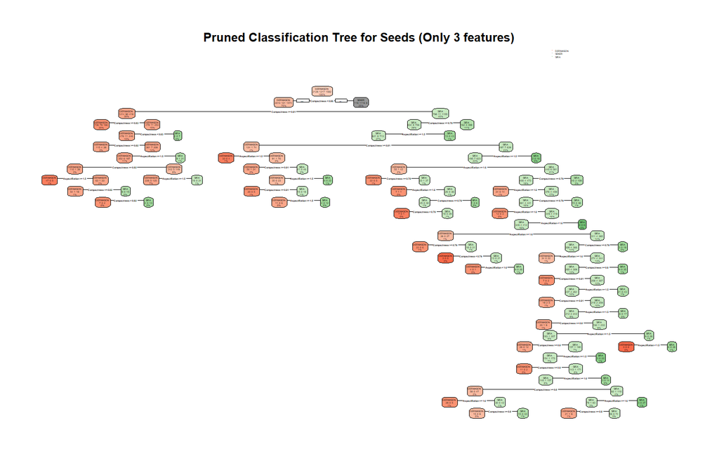

```r
# 11 0.00089318     53  0.411576 0.48589 0.011211

prune_optimal_cp <- dtree_3_full$cptable[which.min(dtree_3_full$cptable[, "xerror"]), "CP"]
dtree_3_pruned <- prune(dtree_3_full, cp = prune_optimal_cp)

rpart.plot(dtree_3_pruned, type = 2, extra = 101, fallen.leaves = F,
           main = "Pruned Classification Tree for Seeds (Only 3 features)")
```

```r
printcp(dtree_3_pruned)
```

```
##
## Classification tree:
## rpart::rpart(formula = Class ~ ., data = seeds_3_training, method = "class",
##     control = rpart.control(minsplit = 1, cp = 0))
##
## Variables actually used in tree construction:
## [1] AspectRation Compactness
##
## Root node error: 2799/4927 = 0.56809
##
## n= 4927
##
##            CP nsplit rel error  xerror     xstd
## 1  0.35655591      0   1.00000 1.00000 0.012422
## 2  0.12826009      1   0.64344 0.64452 0.012081
## 3  0.00595451      2   0.51518 0.51768 0.011426
## 4  0.00232226      5   0.49732 0.50482 0.011342
## 5  0.00202453      7   0.49268 0.51054 0.011380
## 6  0.00178635     10   0.48660 0.50375 0.011334
## 7  0.00160772     14   0.47946 0.49804 0.011296
## 8  0.00151840     37   0.43265 0.49125 0.011248
## 9  0.00142908     41   0.42658 0.49089 0.011246
## 10 0.00107181     45   0.42086 0.48660 0.011216
## 11 0.00089318     53   0.41158 0.48196 0.011182
```

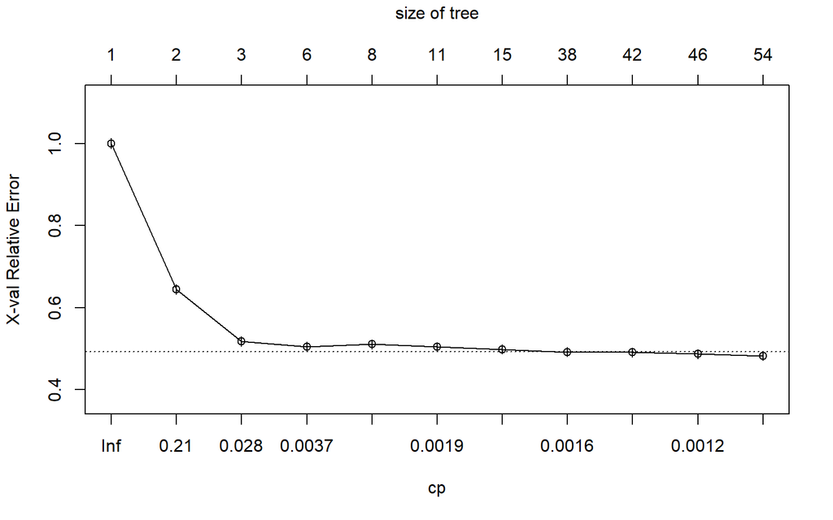

```r
plotcp(dtree_3_pruned)
```

### Confusion Matrix

```r
predict_y_dtree_3_default <- predict(dtree_3_default, newdata = test_x, type = "class") # learn from dtree_default, predict on test_x
predict_y_dtree_3_full <- predict(dtree_3_full, newdata = test_x, type = "class")
predict_y_dtree_3_pruned <- predict(dtree_3_pruned, newdata = test_x, type = "class")

table(predict_y_dtree_3_default,test_y); table(predict_y_dtree_3_full,test_y); table(predict_y_dtree_3_pruned,test_y) # raw confusion matrices
```

```
##                          test_y
## predict_y_dtree_3_default DERMASON SEKER SIRA
##                  DERMASON      795    74  295
##                  SEKER          77   727    9
##                  SIRA          546     9  750
```

```
##                       test_y
## predict_y_dtree_3_full DERMASON SEKER SIRA
##               DERMASON      910   104  494
##               SEKER          83   698   11
##               SIRA          425     8  549
```

```
##                         test_y
## predict_y_dtree_3_pruned DERMASON SEKER SIRA
##                 DERMASON      978    82  442
##                 SEKER          77   727    9
##                 SIRA          363     1  603
```

```r
confusionMatrix(predict_y_dtree_3_default, reference=test_y, mode="prec_recall")
```

```
## Confusion Matrix and Statistics
##
##           Reference
## Prediction DERMASON SEKER SIRA
##   DERMASON      795    74  295
##   SEKER          77   727    9
##   SIRA          546     9  750
##
## Overall Statistics
##
##                Accuracy : 0.6923
##                  95% CI : (0.6762, 0.708)
##     No Information Rate : 0.4321
##     P-Value [Acc > NIR] : < 2.2e-16
##
##                   Kappa : 0.5323
##
##  Mcnemar's Test P-Value : 3.674e-16
##
## Statistics by Class:
##
##                      Class: DERMASON Class: SEKER Class: SIRA
## Precision                     0.6830       0.8942      0.5747
## Recall                        0.5606       0.8975      0.7116
## F1                            0.6158       0.8959      0.6359
## Prevalence                    0.4321       0.2468      0.3211
## Detection Rate                0.2422       0.2215      0.2285
## Detection Prevalence          0.3547       0.2477      0.3976
## Balanced Accuracy             0.6813       0.9314      0.7312
```

```r
confusionMatrix(predict_y_dtree_3_full, reference=test_y, mode="prec_recall")
```

```
## Confusion Matrix and Statistics
##
##           Reference
## Prediction DERMASON SEKER SIRA
##   DERMASON      910   104  494
##   SEKER          83   698   11
##   SIRA          425     8  549
##
## Overall Statistics
##
##                Accuracy : 0.6572
##                  95% CI : (0.6407, 0.6735)
##     No Information Rate : 0.4321
##     P-Value [Acc > NIR] : < 2e-16
##
##                   Kappa : 0.4692
##
##  Mcnemar's Test P-Value : 0.04575
##
## Statistics by Class:
##
##                      Class: DERMASON Class: SEKER Class: SIRA
## Precision                     0.6034       0.8813      0.5591
## Recall                        0.6417       0.8617      0.5209
## F1                            0.6220       0.8714      0.5393
## Prevalence                    0.4321       0.2468      0.3211
## Detection Rate                0.2773       0.2127      0.1673
## Detection Prevalence          0.4595       0.2413      0.2992
## Balanced Accuracy             0.6605       0.9119      0.6633
```

```r
confusionMatrix(predict_y_dtree_3_pruned, reference=test_y, mode="prec_recall")
```

```
## Confusion Matrix and Statistics
##
##           Reference
## Prediction DERMASON SEKER SIRA
##   DERMASON      978    82  442
##   SEKER          77   727    9
##   SIRA          363     1  603
##
## Overall Statistics
##
##                Accuracy : 0.7032
##                  95% CI : (0.6873, 0.7188)
##     No Information Rate : 0.4321
##     P-Value [Acc > NIR] : < 2.2e-16
##
##                   Kappa : 0.541
##
##  Mcnemar's Test P-Value : 0.002512
##
## Statistics by Class:
##
##                      Class: DERMASON Class: SEKER Class: SIRA
## Precision                     0.6511       0.8942      0.6236
## Recall                        0.6897       0.8975      0.5721
## F1                            0.6699       0.8959      0.5967
## Prevalence                    0.4321       0.2468      0.3211
## Detection Rate                0.2980       0.2215      0.1837
## Detection Prevalence          0.4576       0.2477      0.2946
## Balanced Accuracy             0.7043       0.9314      0.7044
```

Different combinations of predictors would definitely affect the model’s performance in various ways.

# Random Forest and Adaboost - 04.02

More libraries needed:

```r
library(data.table) #data manipulation
library(plotly) #nice plots
library(rpart) #rpart for decision trees
library(rpart.plot)
library(caret) # ML tools

library("ranger") # the fastest and better random forest implementation (rf)
library("adabag") # Adaboost
```

Similar handling and preprocessing

```r
seeds <- fread("./data/seeds.csv", na.strings=c("N/A"))
seeds[, Class := as.factor(Class)]

sum(is.na(seeds))
```

```
## [1] 4
```

```r
colSums(is.na(seeds))
```

```
##            Area       Perimeter MajorAxisLength MinorAxisLength    AspectRation
##               0               0               0               0               0
##    Eccentricity      ConvexArea   EquivDiameter          Extent        Solidity
##               1               0               0               0               3
##       roundness     Compactness    ShapeFactor1    ShapeFactor2    ShapeFactor3
##               0               0               0               0               0
##    ShapeFactor4           Class
##               0               0
```

```r
seeds <- na.omit(seeds)
sum(is.na(seeds))
```

```
## [1] 0
```

```r
my_numerical_columns <- colnames(seeds[, .SD, .SDcols = is.numeric])
my_categorical_columns <- colnames(seeds[, .SD, .SDcols = is.factor])

set.seed(12345)

idx <- createDataPartition(seeds[, Class], times=1, p = 0.6, list = F)

seeds_training <- seeds[idx, ]
seeds_test <- seeds[-idx]

train_x <- seeds_training[, !"Class"]
train_y <- seeds_training[, Class]
test_x <- seeds_test[, !"Class"]
test_y <- seeds_test[, Class]
```

## Random Forest

```r
rf.orig <- ranger(x = train_x, y = train_y)
rf.orig
```

```
## Ranger result
##
## Call:
##  ranger(x = train_x, y = train_y)
##
## Type:                             Classification
## Number of trees:                  500
## Sample size:                      4923
## Number of independent variables:  16
## Mtry:                             4
## Target node size:                 1
## Variable importance mode:         none
## Splitrule:                        gini
## OOB prediction error:             7.82 %
```

```r
confusionMatrix(data=rf.orig$predictions, reference = train_y,
                mode="prec_recall")
```

```
## Confusion Matrix and Statistics
##
##           Reference
## Prediction DERMASON SEKER SIRA
##   DERMASON     1984    31  160
##   SEKER          33  1154   21
##   SIRA          110    30 1400
##
## Overall Statistics
##
##                Accuracy : 0.9218
##                  95% CI : (0.9139, 0.9291)
##     No Information Rate : 0.4321
##     P-Value [Acc > NIR] : < 2e-16
##
##                   Kappa : 0.8793
##
##  Mcnemar's Test P-Value : 0.01222
##
## Statistics by Class:
##
##                      Class: DERMASON Class: SEKER Class: SIRA
## Precision                     0.9122       0.9553      0.9091
## Recall                        0.9328       0.9498      0.8855
## F1                            0.9224       0.9525      0.8971
## Prevalence                    0.4321       0.2468      0.3211
## Detection Rate                0.4030       0.2344      0.2844
## Detection Prevalence          0.4418       0.2454      0.3128
## Balanced Accuracy             0.9322       0.9676      0.9218
```

```r
# we see how well the model learned the patterns in the training data
```

Result: - 500 trees were created, 4 features selected for each one, OOB Error low means good accuracy. #NOTE: Good performance on training data.

Predictions:

```r
prediction <- predict(object=rf.orig, data=test_x)
confusionMatrix(data=prediction$predictions, reference=test_y, mode="prec_recall")
```

```
## Confusion Matrix and Statistics
##
##           Reference
## Prediction DERMASON SEKER SIRA
##   DERMASON     1318    21  105
##   SEKER          17   770    9
##   SIRA           83    19  940
##
## Overall Statistics
##
##                Accuracy : 0.9226
##                  95% CI : (0.9129, 0.9315)
##     No Information Rate : 0.4321
##     P-Value [Acc > NIR] : < 2e-16
##
##                   Kappa : 0.8806
##
##  Mcnemar's Test P-Value : 0.08706
##
## Statistics by Class:
##
##                      Class: DERMASON Class: SEKER Class: SIRA
## Precision                     0.9127       0.9673      0.9021
## Recall                        0.9295       0.9506      0.8918
## F1                            0.9210       0.9589      0.8969
## Prevalence                    0.4321       0.2468      0.3211
## Detection Rate                0.4016       0.2346      0.2864
## Detection Prevalence          0.4400       0.2425      0.3175
## Balanced Accuracy             0.9309       0.9700      0.9230
```

```r
# we see the actual performance of our model on data it hasn't seen before
```

Since both of our confusion matrices showed similarly high results, it means that our model performed well on both datasets (train + test), without signs of over- or underfitting.

```r
seeds_training[, .N/nrow(seeds_training), Class]
```

```
##       Class        V1
##      <fctr>     <num>
## 1:    SEKER 0.2468007
## 2: DERMASON 0.4320536
## 3:     SIRA 0.3211456
```

There is no over- or undersampling in the training dataset. No resampling needed.

## Feature Importance

```r
imp_model.perm <- ranger(x = train_x, y = train_y, importance="permutation")
imp_model.impurity <- ranger(x = train_x, y = train_y, importance = "impurity")

imp_table.perm <- data.table(
  Feature = names(imp_model.perm$variable.importance),
  Importance = imp_model.perm$variable.importance
)

# Permutation based importance visualization
a <- plot_ly(data = imp_table.perm, x = ~Feature, y = ~Importance,
             type = "bar", showlegend=FALSE) %>%
  layout(
    xaxis = list(categoryorder = "total descending", title = "Features"),
    yaxis = list(title = "Importance"),
    title = "Feature Importance (Permutation)"
  )

# Permutation based importance visualization
imp_table.purity <- data.table(
  Feature = names(imp_model.impurity$variable.importance),
  Importance = imp_model.impurity$variable.importance
)

b <- plot_ly(data = imp_table.purity,
             x = ~Feature,
             y = ~Importance,
             type = "bar",
             showlegend=FALSE,
             marker = list(color = "orange")) %>%
  layout(
    xaxis = list(categoryorder = "total descending", title = "Features"),
    yaxis = list(title = "Importance"),
    title = "Feature Importance (Mean Decrease Impurity - RF specific)"
  )
a;b
```

[interactive chart not shown]

```r
#plots <- list()
#plots[[1]] <- a
#plots[[2]] <- b
#subplot(plots, nrows = 2, titleY = T, margin = c(0.05,0.05,0.2,0.2))
```

We can observe the differences in the value importance metrics. It’s not just the order, but the metric that is Random Forest specific has more distinct levels.

## Adaboost

**“The output of one model is used to weight the input data of the next model”**

```r
ada <- adabag::boosting(Class ~ ., data = seeds_training, mfinal = 10)
my_pred_adaboost <- predict(ada, newdata = test_x)
confusionMatrix(as.factor(my_pred_adaboost$class), test_y, mode = "prec_recall", positive = "Yes")
```

```
## Confusion Matrix and Statistics
##
##           Reference
## Prediction DERMASON SEKER SIRA
##   DERMASON     1291    13   91
##   SEKER          24   773    9
##   SIRA          103    24  954
##
## Overall Statistics
##
##                Accuracy : 0.9196
##                  95% CI : (0.9097, 0.9286)
##     No Information Rate : 0.4321
##     P-Value [Acc > NIR] : < 2e-16
##
##                   Kappa : 0.8762
##
##  Mcnemar's Test P-Value : 0.01268
##
## Statistics by Class:
##
##                      Class: DERMASON Class: SEKER Class: SIRA
## Precision                     0.9254       0.9591      0.8825
## Recall                        0.9104       0.9543      0.9051
## F1                            0.9179       0.9567      0.8937
## Prevalence                    0.4321       0.2468      0.3211
## Detection Rate                0.3934       0.2355      0.2907
## Detection Prevalence          0.4250       0.2456      0.3294
## Balanced Accuracy             0.9273       0.9705      0.9241
```

I tried multiple adaboost iteration values and found that after 10, the model performance measures didn’t significantly improve (and also computational time increased :,d ). So as not to risk overfitting, the mfinal is set to 10.